# Statistical inference with the GSS data

## Setup

```r
knitr::opts_chunk$set(echo = TRUE,fig.align='center', message = FALSE, warning=FALSE)
```

### Load packages

```r
library(ggplot2)
library(dplyr)
library(statsr)
```

### Load data

```r
load("./data/gss.Rdata")
```

## Part 1: Data

**I) DESCRIPTION**

The data used in this project comes from the **General Social Survey**, which is a sociological survey collected by the University of Chicago. It is one of the most distinguished studies in the social sciences and has been monitoring the change in the society of the United States since 1972. Some of the topics in the GSS are: marijuana use, crime, intergroup relations, social and economic life, lifestyle, civil liberties, sexual behavior, etc.

Consequently, the General Social Survey provides social scientists & statisticians with high-quality data, which can help them identify trends & changes in american society.

**II) METHODOLOGY**

- The target population are adults (18+) living in households in the United States.
- The sample is drawn using a proportional sampling technique, using an area probability design that randomly selects respondents.
- Respondents are from a mix of urban, suburban, and rural geographic areas.
- Participation in the study is voluntary.

**NOTE** that the General Social Survey is indeed, an *observational study.*

Therefore, statistical analyses using this data can only *identify association between independent variables and the outcome of interest.*

## Part 2: Research question

Research Question Is there a considerable income inequality among families of different races in the United States?

Using statistical inference methods, we’ll assess whether the data in the GSS supports the idea of a significant inequality in the income of families from different races.

Remember that, since the GSS is an observational study, we can reveal only association between the variables. In this context, race might as well be a confounding variable, and the difference in incomes may be caused by other social factors such as achievement gaps, size of the family, gender, etc.

## Part 3: Exploratory data analysis

## 3.1) Selecting the Data

For the Exploratory Data Analysis & the subsequent Inference, we’ll use the following variables:

- **coninc (income)**: Total family income in constant dollars (adjusted for inflation).
- **race**: Race of the respondent.
- **finrela**: Personal opinion of family income.

```r
df <- gss %>%
        select(race, coninc, finrela) %>%
        na.omit() %>%
        rename(income = coninc)
```

## Analyzing the Total Number of Survey Respondents

The very first thing we want to do is to get the the number of people sampled by each race. We can easily create a barplot & a table to evaluate this, which is what we’ll do in the following code chunk.

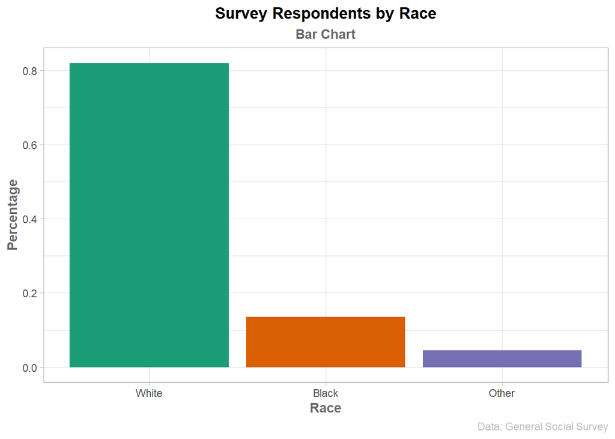

```
## # A tibble: 3 x 3
##   race  n_respondents p_respondents
##   <fct>         <int>         <dbl>
## 1 White         38634        0.820
## 2 Black          6353        0.135
## 3 Other          2105        0.0447
```

## Opinion of Family Income

One of the most interesting variables in this data set is the finrela variable, which categorizes the opinion of the respondent with respect to their family’s income. Using this particular variable, we will analyze whether the income perception differs between races or not.

The following code chunk creates a dataframe, where the percent variable is the relative frequency with respect to each race. (Hence, the percent of each race sums to 1).

**NOTE:** We compare the relative frequencies to adjust for the large difference in sample sizes we found in the last bar chart.

```
## # A tibble: 9 x 3
## # Groups:   race [3]
##   race  finrela       percent
##   <fct> <ord>           <dbl>
## 1 White Below Average  0.273
## 2 White Average        0.497
## 3 White Above Average  0.230
## 4 Black Below Average  0.441
## 5 Black Average        0.463
## 6 Black Above Average  0.0955
## 7 Other Below Average  0.360
## 8 Other Average        0.489
## 9 Other Above Average  0.151
```

Now we can create a barplot using the ggplot2 package in order to visualize the opinion of family income grouped by race.

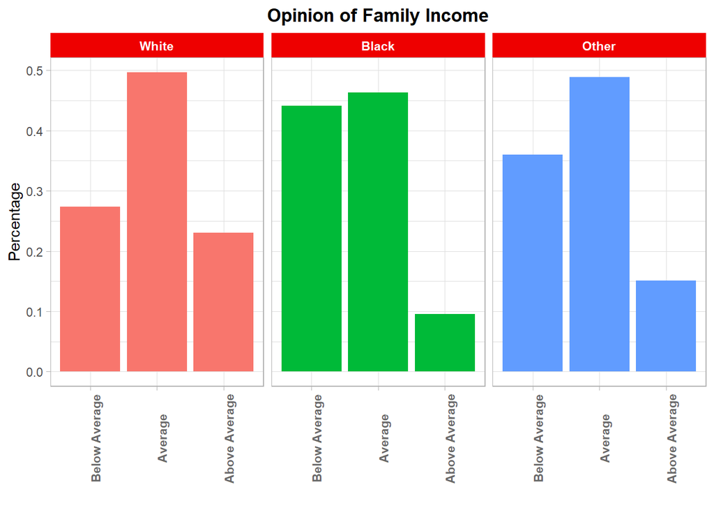

We can observe that the average category is the most frequent one in every single panel. Also, the barplot that represents white people is fairly symmetric. This is not the case with black and other races (the barplot is left-skewed), which clearly implies they have a rather negative view of their family’s income. In summary, we have found that black & other races tend to view themselves as having a below average income, more often than whites. Also, white people tend to view themselves as having an above average income, more often than other races.

This is quite an intriguing result. We’ll see if it’s justified later on…

## Distribution of the Total Family Income

Our next step is to take a quick look at the distribution of the total family income. So far, we’ve seen very few people consider themselves to have an income above average, which is why (empirically) we would expect a distribution skewed to the right.

We’ll check with a histogram & a summary table.

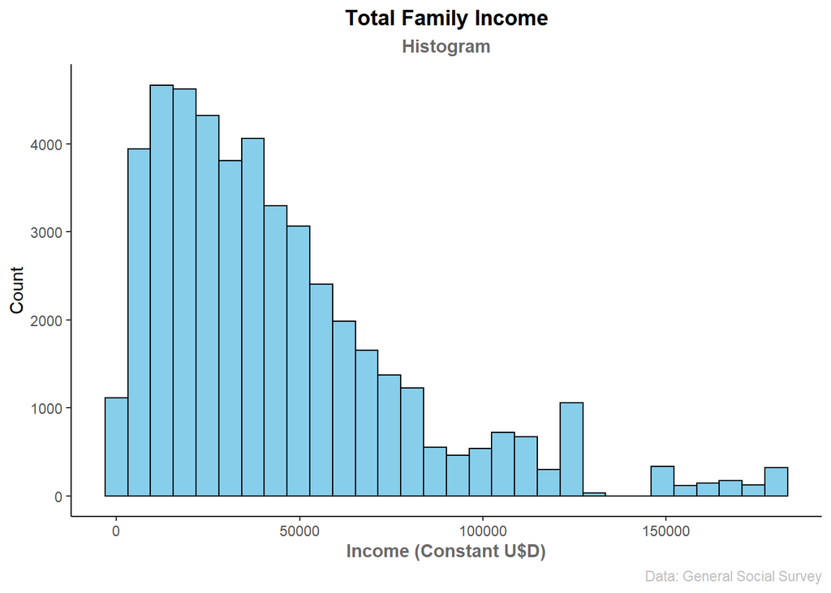

```
##    Min. 1st Qu.  Median    Mean 3rd Qu.    Max.
##     383   18442   35471   44014   58849  180386
```

We can appreciate both in the histogram & summary table, that the distribution of the family income is skewed to the right. However, we also want to see how this relationship varies with respect to each different race, which is our next EDA plot.

# Variability & Mean of Family Income

As aforementioned, we will visualize the variability of the family income when clustered by race. This is why we’ll create a Violin Plot with a Boxplot inside (and also a red dot that represents the mean of each grouped sample).

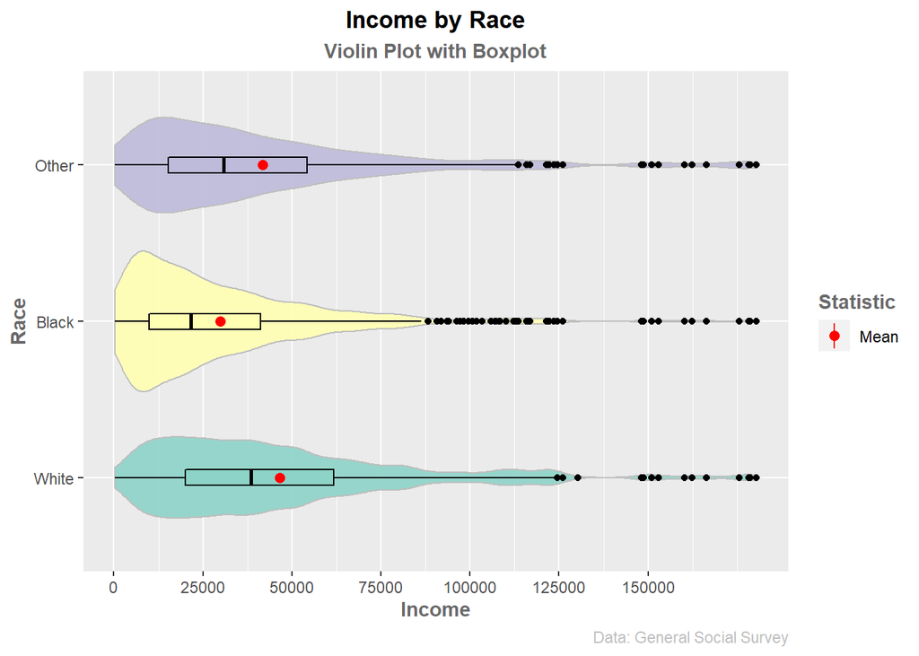

```
## # A tibble: 3 x 4
## # Groups:   race [3]
##   race   X25.  X50.  X75.
##   <fct> <dbl> <dbl> <dbl>
## 1 White 20062 38414 61721
## 2 Black  9953 21688 41223
## 3 Other 15213 30861 54203
```

```
## raceWhite raceBlack raceOther
##  46478.64  29788.42  41707.34
```

Finally, we’ll test this using techniques of Statistical Inference.

## Part 4: Inference

We are going to test whether there is a significant difference in the means of several groups or not. Out of all the Statistical Inference Methods used in introductory courses, the one that is best suited for this problem is **ANOVA**.

So the Null Hypothesis & Alternative Hypothesis are:

# There is no mean that is significantly different

$H_{0}: \mu_{i} = \mu_{j} \$

# There is at least one mean significantly different

$H_{A}: \exists\ \mu_{i}\neq \mu_{j}$

## Statistical Assumptions of the ANOVA Model

#### I) Independence

The data given by the GSS is a Random Sample, so we can assume that each observation is independent.

#### II) Normality

As mentioned earlier, each of the distributions are right-skewed. Nevertheless, because of our large sample we can apply the Central Limit Theorem and meet the assumption of normality.

#### ANOVA Test: Analysis of Variance

```
## Analysis of Variance Table
##
## Response: coninc
##              Df     Sum Sq    Mean Sq F value    Pr(>F)
## race          2 1.6989e+12 8.4944e+11  675.08 < 2.2e-16 ***
## Residuals 51229 6.4461e+13 1.2583e+09
## ---
## Signif. codes:  0 '***' 0.001 '**' 0.01 '*' 0.05 '.' 0.1 ' ' 1
```

The outcome of the ANOVA Test has an F-Statistic of 675.08 and a p-value of less that 2.2e-16, which provides an extremely strong evidence against the Null Hypothesis.

#### Pairwise T Tests: Bonferroni Correction

We can also check the difference in means between each groups, using Pairwise T-tests with Bonferroni Correction

```
##
##  Pairwise comparisons using t tests with pooled SD
##
## data:  test_data$coninc and test_data$race
##
##       White   Black
## Black < 2e-16 -
## Other 1.4e-09 < 2e-16
##
## P value adjustment method: bonferroni
```

#### Conclussion

Thus, we **reject the Null Hypothesis** and accepts the Alternative Hypothesis, we conclude that there is a significant difference in means between groups among at least one pair. Hence, there is an association between race and the total family income.